# Implement SGD Classifier with Logloss and L2 regularization Using SGD without using sklearn

There will be some functions that start with the word "grader" ex: grader_weights(), grader_sigmoid(), grader_logloss() etc, you should not change those function definition.  
Every Grader function has to return True.

Importing packages

```python
import numpy as np
import pandas as pd
from sklearn.datasets import make_classification
from sklearn.model_selection import train_test_split
from sklearn.preprocessing import StandardScaler
from sklearn import linear_model
```

Creating custom dataset

```python
# please don't change random_state
X, y = make_classification(n_samples=50000, n_features=15, n_informative=10, n_redundant=5,
                           n_classes=2, weights=[0.7], class_sep=0.7, random_state=15)
# make_classification is used to create custom dataset
# Please check this link (https://scikit-learn.org/stable/modules/generated/sklearn.datasets.make_classification.html) for more details
```

```python
X.shape, y.shape
```

```
((50000, 15), (50000,))
```

Splitting data into train and test

```python
#please don't change random state
X_train, X_test, y_train, y_test = train_test_split(X, y, test_size=0.25, random_state=15)
```

```python
# Standardizing the data.
scaler = StandardScaler()
x_train = scaler.fit_transform(X_train)
x_test = scaler.transform(X_test)
```

```python
X_train.shape, y_train.shape, X_test.shape, y_test.shape
```

```
((37500, 15), (37500,), (12500, 15), (12500,))
```

# SGD classifier

```python
# alpha : float
# Constant that multiplies the regularization term.

# eta0 : double
# The initial learning rate for the ‘constant’, ‘invscaling’ or ‘adaptive’ schedules.

clf = linear_model.SGDClassifier(eta0=0.0001, alpha=0.0001, loss='log', random_state=15, penalty='l2', tol=1e-3, verbose=2, learning_rate='constant')
clf
# Please check this documentation (https://scikit-learn.org/stable/modules/generated/sklearn.linear_model.SGDClassifier.html)
```

```
SGDClassifier(alpha=0.0001, average=False, class_weight=None, epsilon=0.1,
       eta0=0.0001, fit_intercept=True, l1_ratio=0.15,
       learning_rate='constant', loss='log', max_iter=None, n_iter=None,
       n_jobs=1, penalty='l2', power_t=0.5, random_state=15, shuffle=True,
       tol=0.001, verbose=2, warm_start=False)
```

```python
clf.fit(X=X_train, y=y_train) # fitting our model
```

```
-- Epoch 1
Norm: 0.76, NNZs: 15, Bias: -0.314605, T: 37500, Avg. loss: 0.455801
Total training time: 0.01 seconds.
-- Epoch 2
Norm: 0.92, NNZs: 15, Bias: -0.469578, T: 75000, Avg. loss: 0.394737
Total training time: 0.02 seconds.
-- Epoch 3
Norm: 0.98, NNZs: 15, Bias: -0.580452, T: 112500, Avg. loss: 0.385561
Total training time: 0.03 seconds.
-- Epoch 4
Norm: 1.02, NNZs: 15, Bias: -0.660824, T: 150000, Avg. loss: 0.382161
Total training time: 0.03 seconds.
-- Epoch 5
Norm: 1.04, NNZs: 15, Bias: -0.717218, T: 187500, Avg. loss: 0.380474
Total training time: 0.04 seconds.
-- Epoch 6
Norm: 1.06, NNZs: 15, Bias: -0.761816, T: 225000, Avg. loss: 0.379481
Total training time: 0.05 seconds.
Convergence after 6 epochs took 0.05 seconds
```

```
SGDClassifier(alpha=0.0001, average=False, class_weight=None, epsilon=0.1,
       eta0=0.0001, fit_intercept=True, l1_ratio=0.15,
       learning_rate='constant', loss='log', max_iter=None, n_iter=None,
       n_jobs=1, penalty='l2', power_t=0.5, random_state=15, shuffle=True,
       tol=0.001, verbose=2, warm_start=False)
```

```python
clf.coef_, clf.coef_.shape, clf.intercept_
#clf.coef_ will return the weights
#clf.coef_.shape will return the shape of weights
#clf.intercept_ will return the intercept term
```

```
(array([[-0.41177431,  0.18416782, -0.13895073,  0.33572511, -0.18423237,
          0.5494352 , -0.45213692, -0.08857465,  0.21536661,  0.17351757,
          0.18480827,  0.00443463, -0.07033001,  0.33683181,  0.02004129]]),
 (1, 15),
 array([-0.76181561]))
```

[output not shown]

## Implement Logistic Regression with L2 regularization Using SGD: without using sklearn

1. We will be giving you some functions, please write code in that functions only.
2. After every function, we will be giving you expected output, please make sure that you get that output.
- Initialize the weight_vector and intercept term to zeros (Write your code in def initialize_weights())
- Create a loss function (Write your code in def logloss())

  $log loss = -1*\frac{1}{n}\Sigma_{for each Yt,Y_{pred}}(Ytlog10(Y_{pred})+(1-Yt)log10(1-Y_{pred}))$
- for each epoch:
  - for each batch of data points in train: (keep batch size=1)
    - calculate the gradient of loss function w.r.t each weight in weight vector (write your code in def gradient_dw())

      $dw^{(t)} = x_n(y_n − σ((w^{(t)})^{T} x_n+b^{t}))- \frac{λ}{N}w^{(t)})$
    - Calculate the gradient of the intercept (write your code in def gradient_db()) [check this](https://drive.google.com/file/d/1nQ08-XY4zvOLzRX-lGf8EYB5arb7-m1H/view?usp=sharing)

      $ db^{(t)} = y_n- σ((w^{(t)})^{T} x_n+b^{t}))$
    - Update weights and intercept (check the equation number 32 in the above mentioned [pdf](https://drive.google.com/file/d/1nQ08-XY4zvOLzRX-lGf8EYB5arb7-m1H/view?usp=sharing)):  
      $w^{(t+1)}← w^{(t)}+α(dw^{(t)}) $

      $b^{(t+1)}←b^{(t)}+α(db^{(t)}) $
  - calculate the log loss for train and test with the updated weights (you can check the python assignment 10th question)
  - And if you wish, you can compare the previous loss and the current loss, if it is not updating, then you can stop the training
  - append this loss in the list ( this will be used to see how loss is changing for each epoch after the training is over )

Initialize weights

```python
def initialize_weights(dim):
    ''' In this function, we will initialize our weights and bias'''
    #initialize the weights to zeros array of (1,dim) dimensions
    #you use zeros_like function to initialize zero, check this link https://docs.scipy.org/doc/numpy/reference/generated/numpy.zeros_like.html
    #initialize bias to zero
    b=0
    x=np.arange(len(dim))
    x=x.reshape(len(dim))
    w=np.zeros_like(x)

    return w,b
```

```python
dim=X_train[0]
w,b = initialize_weights(dim)
print('w =',(w))
print('b =',str(b))
```

```
w = [0 0 0 0 0 0 0 0 0 0 0 0 0 0 0]
b = 0
```

Grader function - 1

```python
dim=X_train[0]
w,b = initialize_weights(dim)
def grader_weights(w,b):
  assert((len(w)==len(dim)) and b==0 and np.sum(w)==0.0)
  return True
grader_weights(w,b)
```

```
True
```

Compute sigmoid

$sigmoid(z)= 1/(1+exp(-z))$

```python
import math
def sigmoid(z):
    ''' In this function, we will return sigmoid of z'''
    # compute sigmoid(z) and return
    s=1/(1+np.exp(-z))


    return s
```

Grader function - 2

```python
def grader_sigmoid(z):
  val=sigmoid(z)
  assert(val==0.8807970779778823)
  return True
grader_sigmoid(2)
```

```
True
```

Compute loss

$log loss = -1*\frac{1}{n}\Sigma_{for each Yt,Y_{pred}}(Ytlog10(Y_{pred})+(1-Yt)log10(1-Y_{pred}))$

```python
def logloss(y_true,y_pred):
    '''In this function, we will compute log loss '''
    np.seterr(divide = 'ignore')
    x=0
    for i in range(len(y_true)):
        x+=(((y_true[i])*(np.log10(y_pred[i]))) + ((1-y_true[i])*(np.log10((1-y_pred[i])))))
    loss=(-(x)/len(y_true))
    #print(loss)
    return loss
```

Grader function - 3

```python
def grader_logloss(true,pred):
  loss=logloss(true,pred)
  assert(loss==0.07644900402910389)
  return True
true=[1,1,0,1,0]
pred=[0.9,0.8,0.1,0.8,0.2]
grader_logloss(true,pred)
```

```
True
```

Compute gradient w.r.to 'w'

$dw^{(t)} = x_n(y_n − σ((w^{(t)})^{T} x_n+b^{t}))- \frac{λ}{N}w^{(t)}$

```python
def gradient_dw(x,y,w,b,alpha,N):
    '''In this function, we will compute the gardient w.r.to w '''
    dw=[]
    reg=((w * alpha)/N)
    #print(reg)
    dw=(x*(y-sigmoid(np.dot(np.transpose(w),x)+b))) - (reg)

    return dw
```

Grader function - 4

```python
def grader_dw(x,y,w,b,alpha,N):
  grad_dw=gradient_dw(x,y,w,b,alpha,N)
  assert(np.sum(grad_dw)==2.613689585)
  return True
grad_x=np.array([-2.07864835,  3.31604252, -0.79104357, -3.87045546, -1.14783286,
       -2.81434437, -0.86771071, -0.04073287,  0.84827878,  1.99451725,
        3.67152472,  0.01451875,  2.01062888,  0.07373904, -5.54586092])
grad_y=0
grad_w,grad_b=initialize_weights(grad_x)
alpha=0.0001
N=len(X_train)
grader_dw(grad_x,grad_y,grad_w,grad_b,alpha,N)
```

```
True
```

Compute gradient w.r.to 'b'

$ db^{(t)} = y_n- σ((w^{(t)})^{T} x_n+b^{t})$

```python
def gradient_db(x,y,w,b):
    '''In this function, we will compute gradient w.r.to b '''
    db=[]
    db=(y-sigmoid(np.dot(np.transpose(w),x) + b))
    return db
```

Grader function - 5

```python
def grader_db(x,y,w,b):
  grad_db=gradient_db(x,y,w,b)
  assert(grad_db==-0.5)
  return True
grad_x=np.array([-2.07864835,  3.31604252, -0.79104357, -3.87045546, -1.14783286,
       -2.81434437, -0.86771071, -0.04073287,  0.84827878,  1.99451725,
        3.67152472,  0.01451875,  2.01062888,  0.07373904, -5.54586092])
grad_y=0
grad_w,grad_b=initialize_weights(grad_x)
alpha=0.0001
N=len(X_train)
grader_db(grad_x,grad_y,grad_w,grad_b)
```

```
True
```

Implementing logistic regression

```python
def train(X_train,y_train,X_test,y_test,epochs,alpha,eta0):
    ''' In this function, we will implement logistic regression'''
    #Here eta0 is learning rate
    #implement the code as follows
    # initalize the weights (call the initialize_weights(X_train[0]) function)
    w,b=initialize_weights(X_train[0])

    # for every epoch
    loss_train=[]
    loss_test=[]
    loss_train.append(0)
    loss_test.append(0)
    for epo in range(epochs):

        for i in range(len(X_train)):
            w_g= gradient_dw(X_train[i],y_train[i],w,b,alpha,len(X_train))
            b_g= gradient_db(X_train[i],y_train[i],w,b)
            #print(w_g)
            w=w + (eta0*w_g)
            b=b + (eta0*b_g)


        y_p_train,prob_pre_train=pred_y_check(w,b,X_train)
        loss=logloss(y_train,prob_pre_train)

        loss_train.append(loss)

        y_p_test, prob_pre_test=pred_y_check(w,b,X_test)
        Loss=logloss(y_test, prob_pre_test)
        loss_test.append(Loss)
        print("Train loss ",loss,"Test loss", Loss,"epoch ",epo)

        if (abs(loss_train[epo]-loss_train[epo+1])< 1e-3) & (abs(loss_test[epo]-loss_test[epo+1])< 1e-3):
            print("break happened")
            break
        # for every data point(X_train,y_train)
           #compute gradient w.r.to w (call the gradient_dw() function)
           #compute gradient w.r.to b (call the gradient_db() function)
           #update w, b
        # predict the output of x_train[for all data points in X_train] using w,b
        #compute the loss between predicted and actual values (call the loss function)
        # store all the train loss values in a list
        # predict the output of x_test[for all data points in X_test] using w,b
        #compute the loss between predicted and actual values (call the loss function)
        # store all the test loss values in a list
        # you can also compare previous loss and current loss, if loss is not updating then stop the process and return w,b

    return w,b,loss_test,loss_train
```

```python
alpha=0.0001
eta0=0.0001
N=len(X_train)
epochs=50
w,b,loss,Loss=train(X_train,y_train,X_test,y_test,epochs,alpha,eta0)
print("\nThe optimum w and b are\n", w, b)
print("\nThe Trian and Loss for optimum w and b are \nTrain Loss: ", Loss[-1],"\nTest Loss: ", loss[-1])
```

[output not shown]

Goal of assignment

Compare your implementation and SGDClassifier's the weights and intercept, make sure they are as close as possible i.e difference should be in terms of 10^-3

```python
# these are the results we got after we implemented sgd and found the optimal weights and intercept
w-clf.coef_, b-clf.intercept_
```

```
(array([[ 1.17619247e-02, -8.78541301e-04,  4.92855846e-03,
          7.80752409e-05,  5.34085182e-03, -3.85207210e-03,
          5.44702177e-03, -8.66045608e-03, -1.07119764e-02,
         -1.86587241e-02, -2.11120186e-03,  6.54901415e-03,
          4.20616355e-03,  2.63771503e-04,  2.92174301e-05]]),
 array([0.043393]))
```

Plot epoch number vs train , test loss

- epoch number on X-axis
- loss on Y-axis

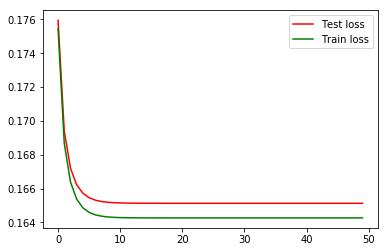

```python
#Without the if condition
import matplotlib.pyplot as plt
e=[i for i in range(50)]
plt.plot(e,loss[1:51],c="red",label="Test loss")
plt.plot(e,Loss[1:51],c="green",label="Train loss")
plt.legend()

plt.show()
```

```python
def pred_y_check(w,b, X):
    N = len(X)
    predict = []
    prob_pre=[]
    for i in range(N):
        z=np.dot(w,X[i])+b
        prob_pre.append(sigmoid(z))
        if sigmoid(z) >= 0.5: # sigmoid(w,x,b) returns 1/(1+exp(-(dot(x,w)+b)))
            predict.append(1)
        else:
            predict.append(0)
    return np.array(predict), np.array(prob_pre)
p_y,prob_y=pred_y_check(w,b,X_train)
xx,xy=pred_y_check(w,b,X_test)
print(1-np.sum(y_train - p_y)/len(X_train))
print(1-np.sum(y_test  - xx)/len(X_test))
```

```
0.96512
0.96272
```